# **Supervised Learning - Foundations Project: ReCell**

## **Problem Statement**

### Business Context

Buying and selling used phones and tablets used to be something that happened on a handful of online marketplace sites. But the used and refurbished device market has grown considerably over the past decade, and a new IDC (International Data Corporation) forecast predicts that the used phone market would be worth \$52.7bn by 2023 with a compound annual growth rate (CAGR) of 13.6% from 2018 to 2023. This growth can be attributed to an uptick in demand for used phones and tablets that offer considerable savings compared with new models.

Refurbished and used devices continue to provide cost-effective alternatives to both consumers and businesses that are looking to save money when purchasing one. There are plenty of other benefits associated with the used device market. Used and refurbished devices can be sold with warranties and can also be insured with proof of purchase. Third-party vendors/platforms, such as Verizon, Amazon, etc., provide attractive offers to customers for refurbished devices. Maximizing the longevity of devices through second-hand trade also reduces their environmental impact and helps in recycling and reducing waste. The impact of the COVID-19 outbreak may further boost this segment as consumers cut back on discretionary spending and buy phones and tablets only for immediate needs.

### Objective

The rising potential of this comparatively under-the-radar market fuels the need for an ML-based solution to develop a dynamic pricing strategy for used and refurbished devices. ReCell, a startup aiming to tap the potential in this market, has hired you as a data scientist. They want you to analyze the data provided and build a linear regression model to predict the price of a used phone/tablet and identify factors that significantly influence it.

### Data Description

The data contains the different attributes of used/refurbished phones and tablets. The data was collected in the year 2021. The detailed data dictionary is given below.

- brand_name: Name of manufacturing brand
- os: OS on which the device runs
- screen_size: Size of the screen in cm
- 4g: Whether 4G is available or not
- 5g: Whether 5G is available or not
- main_camera_mp: Resolution of the rear camera in megapixels
- selfie_camera_mp: Resolution of the front camera in megapixels
- int_memory: Amount of internal memory (ROM) in GB
- ram: Amount of RAM in GB
- battery: Energy capacity of the device battery in mAh
- weight: Weight of the device in grams
- release_year: Year when the device model was released
- days_used: Number of days the used/refurbished device has been used
- normalized_new_price: Normalized price of a new device of the same model in euros
- normalized_used_price: Normalized price of the used/refurbished device in euros

## **Setting Up**

```python
import numpy as np
import pandas as pd

import matplotlib.pyplot as plt
import seaborn as sns

sns.set()

from sklearn.model_selection import train_test_split

from sklearn.linear_model import LinearRegression

from sklearn.metrics import mean_absolute_error, mean_squared_error, r2_score

import statsmodels.api as sm

from statsmodels.stats.outliers_influence import variance_inflation_factor
```

```python
import warnings
warnings.simplefilter(action='ignore', category=FutureWarning)
```

```python
from google.colab import drive
drive.mount('/content/drive')
```

```python
df = pd.read_csv('/content/drive/MyDrive/Data Science & Business Analytics Program/Supervised Learning/Project/used_device_data.csv')
```

## **Data Overview**

### **Shape and Statistical Summary of Data**

```python
df.head()
```

|  | brand_name | os | screen_size | 4g | 5g | main_camera_mp | selfie_camera_mp | int_memory | ram | battery | weight | release_year | days_used | normalized_used_price | normalized_new_price |
| --- | --- | --- | --- | --- | --- | --- | --- | --- | --- | --- | --- | --- | --- | --- | --- |
| 0 | Honor | Android | 14.50 | yes | no | 13.0 | 5.0 | 64.0 | 3.0 | 3020.0 | 146.0 | 2020 | 127 | 4.307572 | 4.715100 |
| 1 | Honor | Android | 17.30 | yes | yes | 13.0 | 16.0 | 128.0 | 8.0 | 4300.0 | 213.0 | 2020 | 325 | 5.162097 | 5.519018 |
| 2 | Honor | Android | 16.69 | yes | yes | 13.0 | 8.0 | 128.0 | 8.0 | 4200.0 | 213.0 | 2020 | 162 | 5.111084 | 5.884631 |
| 3 | Honor | Android | 25.50 | yes | yes | 13.0 | 8.0 | 64.0 | 6.0 | 7250.0 | 480.0 | 2020 | 345 | 5.135387 | 5.630961 |
| 4 | Honor | Android | 15.32 | yes | no | 13.0 | 8.0 | 64.0 | 3.0 | 5000.0 | 185.0 | 2020 | 293 | 4.389995 | 4.947837 |

```python
df.shape
```

```
(3454, 15)
```

```python
df.info()
```

```
<class 'pandas.core.frame.DataFrame'>
RangeIndex: 3454 entries, 0 to 3453
Data columns (total 15 columns):
 #   Column                 Non-Null Count  Dtype
---  ------                 --------------  -----
 0   brand_name             3454 non-null   object
 1   os                     3454 non-null   object
 2   screen_size            3454 non-null   float64
 3   4g                     3454 non-null   object
 4   5g                     3454 non-null   object
 5   main_camera_mp         3275 non-null   float64
 6   selfie_camera_mp       3452 non-null   float64
 7   int_memory             3450 non-null   float64
 8   ram                    3450 non-null   float64
 9   battery                3448 non-null   float64
 10  weight                 3447 non-null   float64
 11  release_year           3454 non-null   int64
 12  days_used              3454 non-null   int64
 13  normalized_used_price  3454 non-null   float64
 14  normalized_new_price   3454 non-null   float64
dtypes: float64(9), int64(2), object(4)
memory usage: 404.9+ KB
```

```python
df.describe(include="all").T
```

|  | count | unique | top | freq | mean | std | min | 25% | 50% | 75% | max |
| --- | --- | --- | --- | --- | --- | --- | --- | --- | --- | --- | --- |
| brand_name | 3454 | 34 | Others | 502 | NaN | NaN | NaN | NaN | NaN | NaN | NaN |
| os | 3454 | 4 | Android | 3214 | NaN | NaN | NaN | NaN | NaN | NaN | NaN |
| screen_size | 3454.0 | NaN | NaN | NaN | 13.713115 | 3.80528 | 5.08 | 12.7 | 12.83 | 15.34 | 30.71 |
| 4g | 3454 | 2 | yes | 2335 | NaN | NaN | NaN | NaN | NaN | NaN | NaN |
| 5g | 3454 | 2 | no | 3302 | NaN | NaN | NaN | NaN | NaN | NaN | NaN |
| main_camera_mp | 3275.0 | NaN | NaN | NaN | 9.460208 | 4.815461 | 0.08 | 5.0 | 8.0 | 13.0 | 48.0 |
| selfie_camera_mp | 3452.0 | NaN | NaN | NaN | 6.554229 | 6.970372 | 0.0 | 2.0 | 5.0 | 8.0 | 32.0 |
| int_memory | 3450.0 | NaN | NaN | NaN | 54.573099 | 84.972371 | 0.01 | 16.0 | 32.0 | 64.0 | 1024.0 |
| ram | 3450.0 | NaN | NaN | NaN | 4.036122 | 1.365105 | 0.02 | 4.0 | 4.0 | 4.0 | 12.0 |
| battery | 3448.0 | NaN | NaN | NaN | 3133.402697 | 1299.682844 | 500.0 | 2100.0 | 3000.0 | 4000.0 | 9720.0 |
| weight | 3447.0 | NaN | NaN | NaN | 182.751871 | 88.413228 | 69.0 | 142.0 | 160.0 | 185.0 | 855.0 |
| release_year | 3454.0 | NaN | NaN | NaN | 2015.965258 | 2.298455 | 2013.0 | 2014.0 | 2015.5 | 2018.0 | 2020.0 |
| days_used | 3454.0 | NaN | NaN | NaN | 674.869716 | 248.580166 | 91.0 | 533.5 | 690.5 | 868.75 | 1094.0 |
| normalized_used_price | 3454.0 | NaN | NaN | NaN | 4.364712 | 0.588914 | 1.536867 | 4.033931 | 4.405133 | 4.7557 | 6.619433 |
| normalized_new_price | 3454.0 | NaN | NaN | NaN | 5.233107 | 0.683637 | 2.901422 | 4.790342 | 5.245892 | 5.673718 | 7.847841 |

### **Checking for Missing or Values**

```python
df.isnull().sum()
```

```
brand_name                 0
os                         0
screen_size                0
4g                         0
5g                         0
main_camera_mp           179
selfie_camera_mp           2
int_memory                 4
ram                        4
battery                    6
weight                     7
release_year               0
days_used                  0
normalized_used_price      0
normalized_new_price       0
dtype: int64
```

```python
df.duplicated().sum()
```

```
0
```

```python
data = df.copy()
```

## **Exploratory Data Analysis**

### **Univariate Analysis**

#### Analyzing Variables by Comparing Their Boxplots and Histograms

```python
def histogram_boxplot(data, feature, figsize=(15, 10), kde=False, bins=None):

    f2, (ax_box2, ax_hist2) = plt.subplots(
        nrows=2,
        sharex=True,
        gridspec_kw={"height_ratios": (0.25, 0.75)},
        figsize=figsize,
    )
    sns.boxplot(
        data=data, x=feature, ax=ax_box2, showmeans=True, color="violet"
    )
    sns.histplot(
        data=data, x=feature, kde=kde, ax=ax_hist2, bins=bins
    ) if bins else sns.histplot(
        data=data, x=feature, kde=kde, ax=ax_hist2
    )
    ax_hist2.axvline(
        data[feature].mean(), color="blue", linestyle="--"
    )
    ax_hist2.axvline(
        data[feature].median(), color="yellow", linestyle="-"
    )
```

**Normalized Price of Used Device in Euros**

The normalized price of the used device on average is around 4.3 euros. The distribution is slightly skewed to the left, but nonetheless follows a normal distribution pattern.

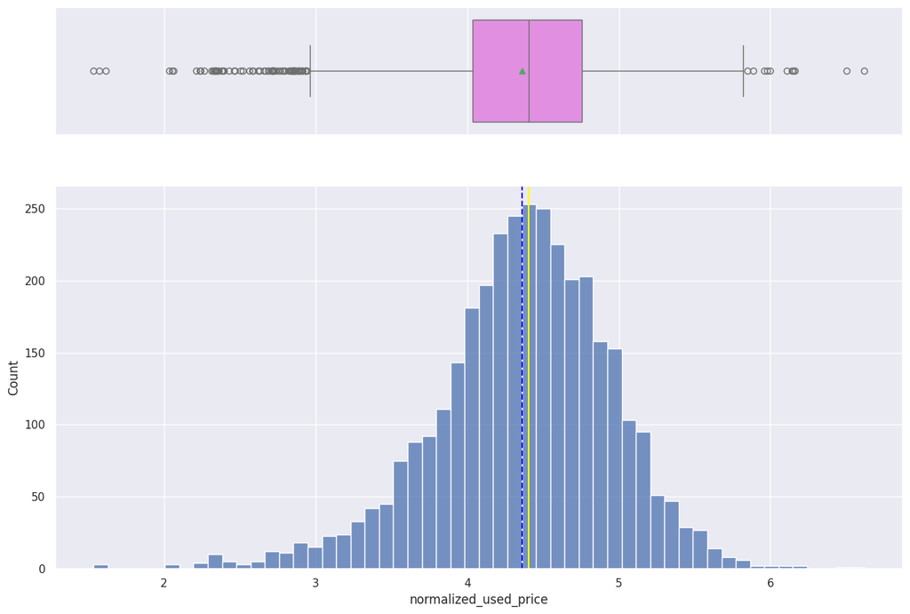

```python
histogram_boxplot(df, "normalized_used_price")
```

**Normalized Price of New Device of the Same Model in Euros**

The distribution for this variable mostly follows the normal distribution pattern, but towards the middle, the numbers are more randomly varied.

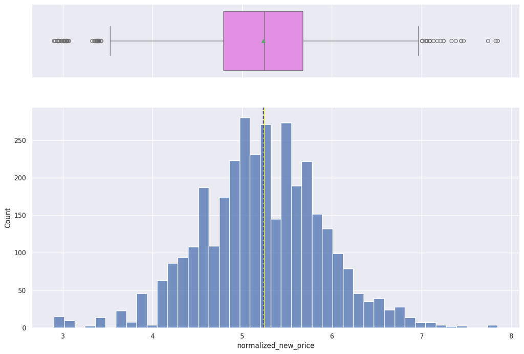

```python
histogram_boxplot(df,"normalized_new_price")
```

**Size of the Screen in cm**

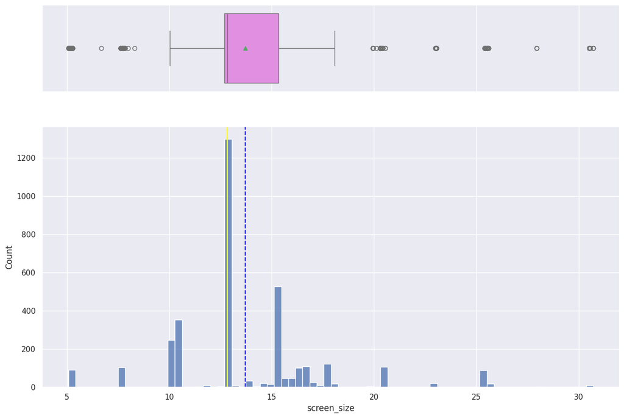

```python
histogram_boxplot(df, "screen_size")
```

**Resolution of the Rear Camera in Megapixels**

This data is skewed to the right. While the mean is approximately 9.460, the data spikes at around 13.

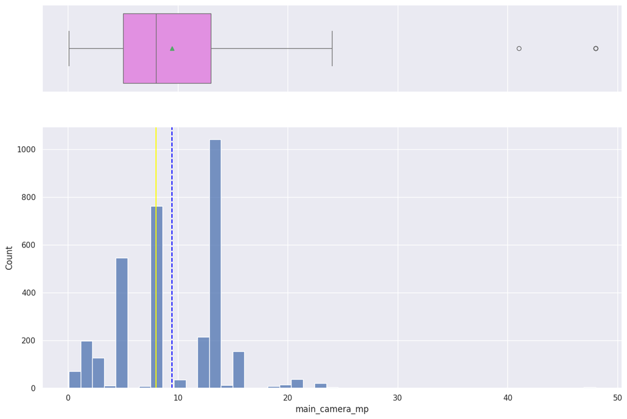

```python
histogram_boxplot(df, "main_camera_mp")
```

**Resolution of the Front Camera in Megapixels**

Similar to the rear camera, the distribution of the front camera resolution tends to skew to the right.

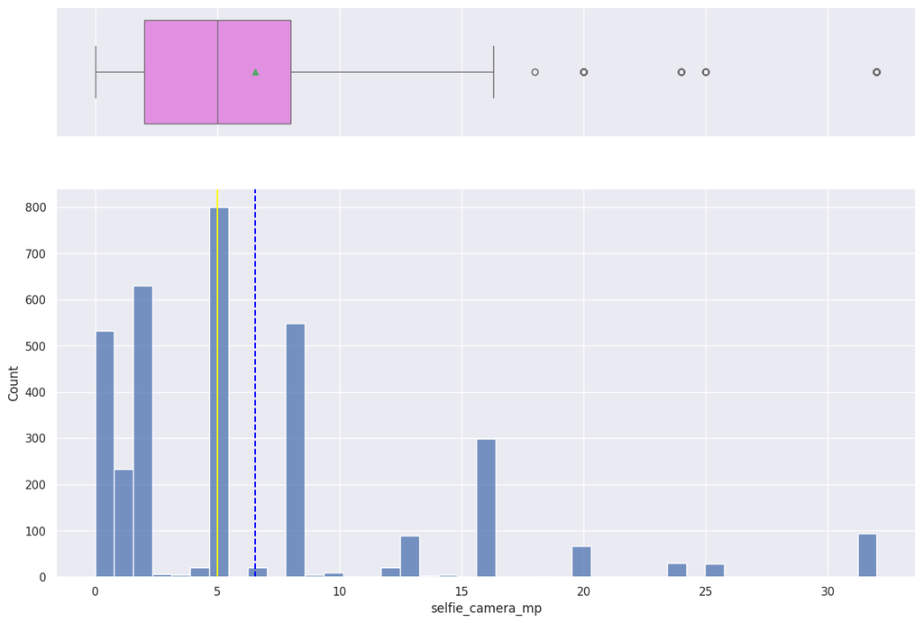

```python
histogram_boxplot(df, "selfie_camera_mp")
```

**Amount of Internal Memory (ROM) in GB**

The data is heavily skewed to the right, as most phones, on average, have around 55 GB in ROM.

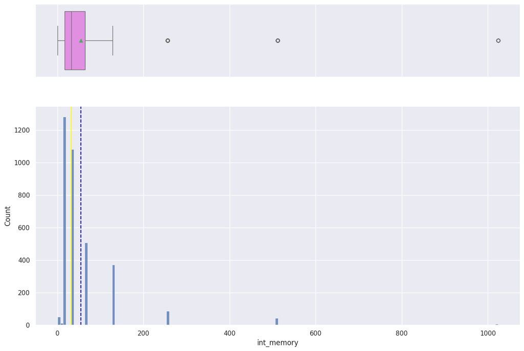

```python
histogram_boxplot(df, "int_memory")
```

**Amount of RAM in GB**

The boxplot for RAM only shows the median and outliers, while the histogram tells us that more than 2500 devices in the data has around 4 GB of RAM.

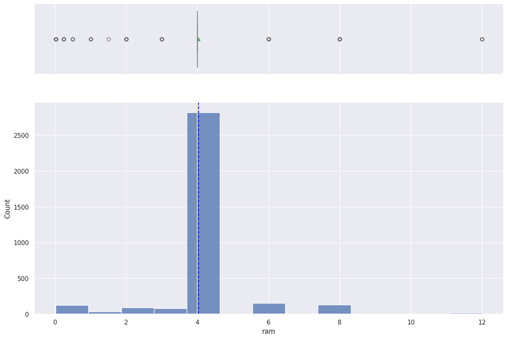

```python
histogram_boxplot(df, "ram")
```

**Weight of Devices in Grams**

The data is heavily skewed to the right. The mean centers around 183 grams, but the heaviest device is weighed upto 855 grams.

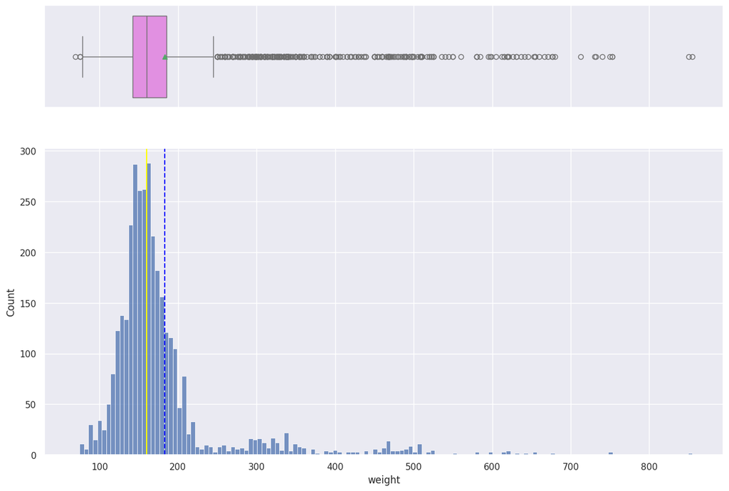

```python
histogram_boxplot(df, "weight")
```

**Energy Capacity of the Device Battery in mAh**

The distribution is very skewed to the right and most devices have around 3000 mAh in energy capacity.

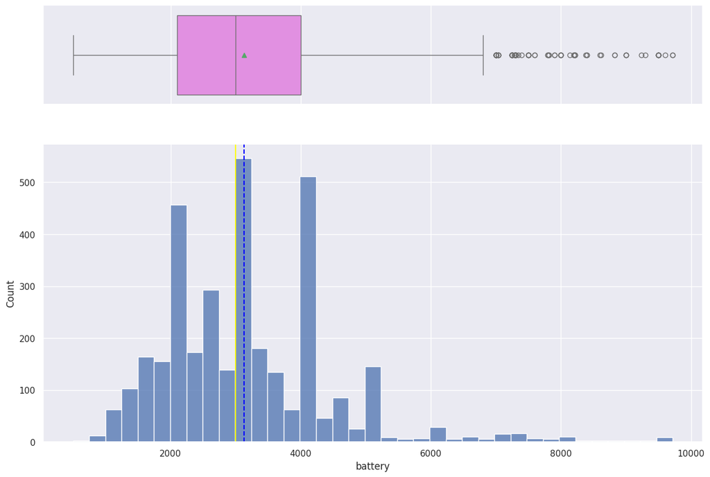

```python
histogram_boxplot(df, "battery")
```

**Number of Days Used Device Has Been Used**

The average number of days people use the refurbished devices is around 675. The data has a slightly left-skewed distribution, but most used devices are used for at least 600 days.

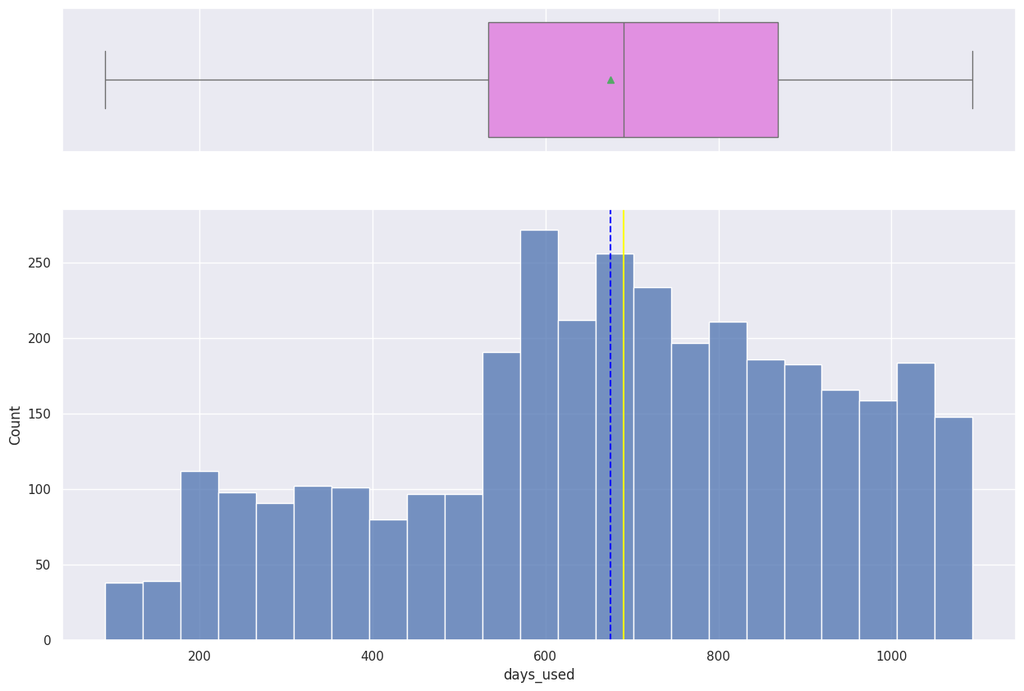

```python
histogram_boxplot(df, "days_used")
```

#### Analyzing Variables With Labeled Barplots

```python
def labeled_barplot(data, feature, perc=False, n=None):

    total = len(data[feature])
    count = data[feature].nunique()
    if n is None:
        plt.figure(figsize=(count + 2, 6))
    else:
        plt.figure(figsize=(n + 2, 6))

    plt.xticks(rotation=90, fontsize=15)
    ax = sns.countplot(
        data=data,
        x=feature,
        palette="Paired",
        order=data[feature].value_counts().index[:n],
    )

    for p in ax.patches:
        if perc == True:
            label = "{:.1f}%".format(
                100 * p.get_height() / total
            )
        else:
            label = p.get_height()

        x = p.get_x() + p.get_width() / 2
        y = p.get_height()

        ax.annotate(
            label,
            (x, y),
            ha="center",
            va="center",
            size=12,
            xytext=(0, 5),
            textcoords="offset points",
        )
    plt.show()
```

**Name of Manufacturing Brand**

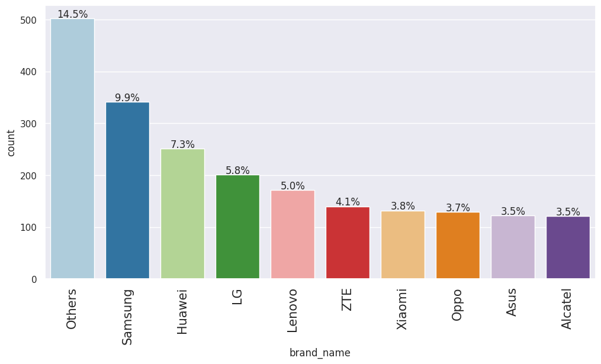

```python
labeled_barplot(df, "brand_name", perc=True, n=10)
```

**OS That Device Runs On**

The overwhelming majority of devices runs on Android with 93.1%. Surprisingly, those that run on iOS only account for 1.0%.

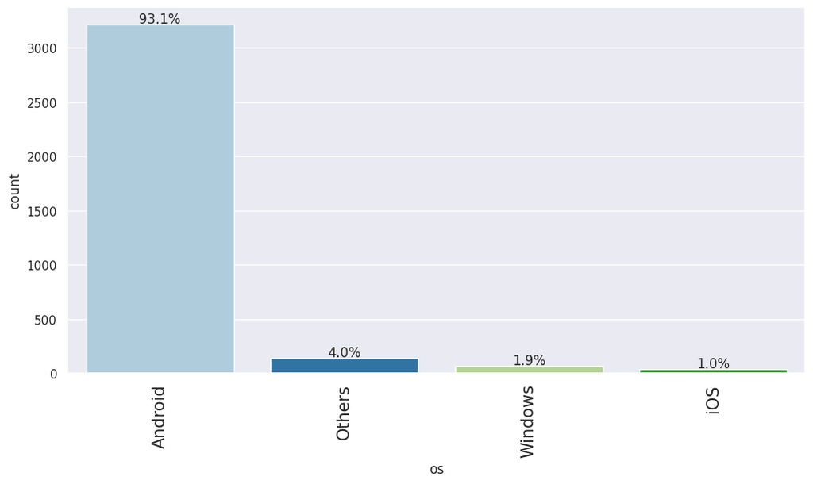

```python
labeled_barplot(df, "os", perc=True, n=10)
```

**4G Availability**

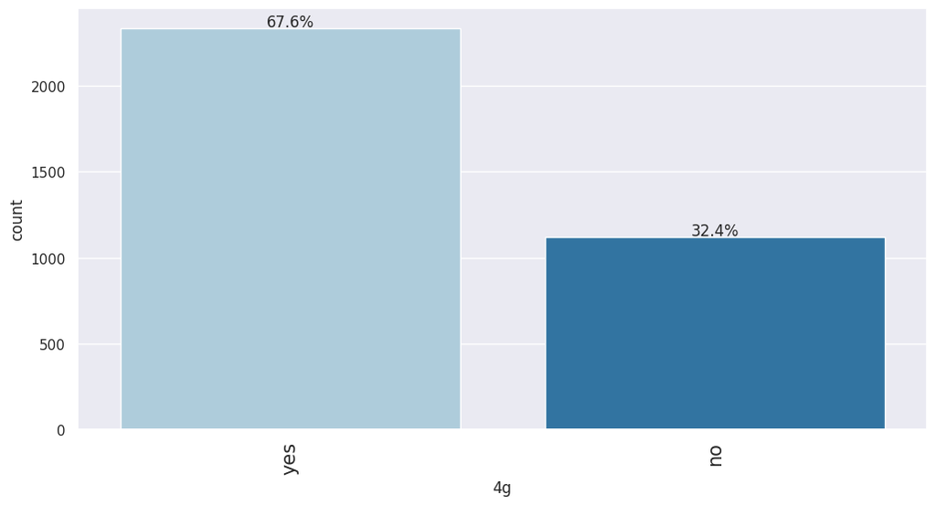

```python
labeled_barplot(df, "4g", perc=True, n=10)
```

**5G Availability**

Only 4.4% of devices have 5g, which can be attributed to this feature being recent technology and many phones have been out for sale way before that.

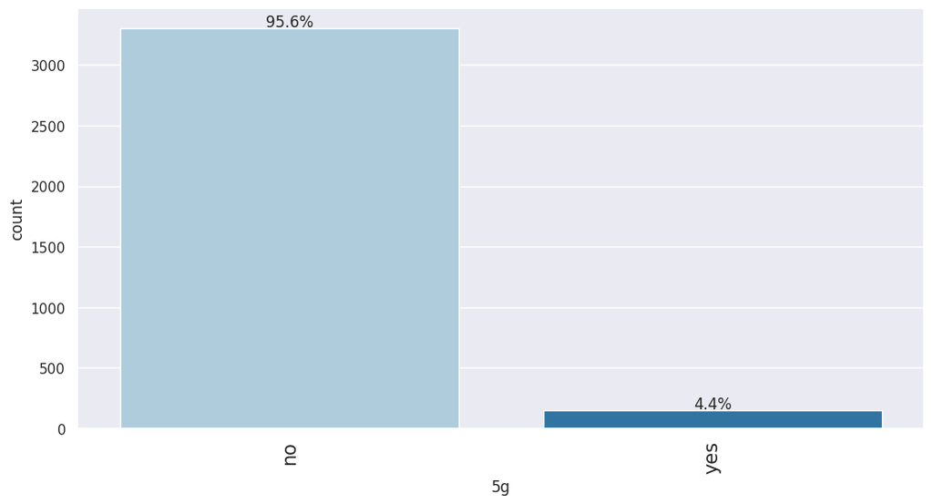

```python
labeled_barplot(df, "5g", perc=True, n=10)
```

**Release Year of Device**

Most of the devices are released between 2013 and 2015, which account for 50% of all phones in the data. Only about a fifth of which are released in in 2019 and after.

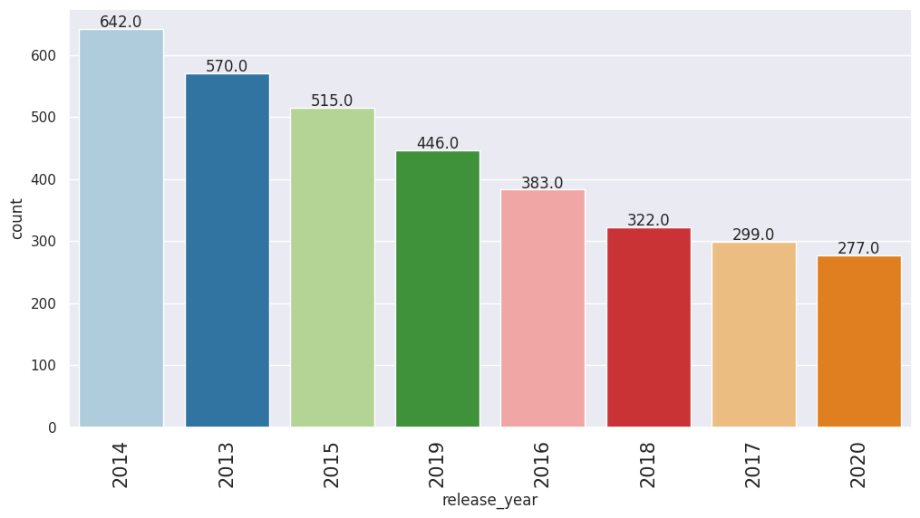

```python
labeled_barplot(df, "release_year", perc=False, n=10)
```

### **Bivariate Analysis**

**Price Variability Between Devices with 4G vs 5G Networks**

Devices that have 4g or 5g, both new and used, tend to cost more than those that do not. It should be noted that new phones that do not have 5g cost similarly to used phones that 5g.

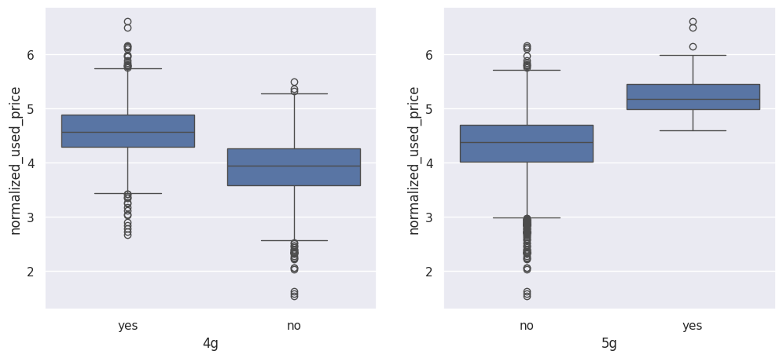

```python
plt.figure(figsize=(12, 5))

plt.subplot(121)
sns.boxplot(data=df, x="4g", y="normalized_used_price")

plt.subplot(122)
sns.boxplot(data=df, x="5g", y="normalized_used_price")

plt.show()
```

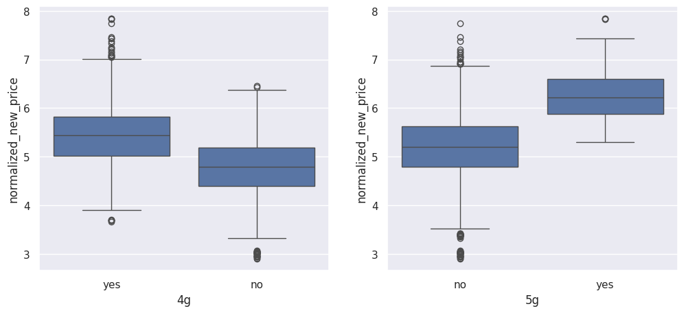

```python
plt.figure(figsize=(12, 5))

plt.subplot(121)
sns.boxplot(data=df, x="4g", y="normalized_new_price")

plt.subplot(122)
sns.boxplot(data=df, x="5g", y="normalized_new_price")

plt.show()
```

**Brands with Large Screen Size**

It appears that Huawei and Samsung offer more devices than any other brand with large screen size that is larger than 15.24 cm. Apple and Acer both have the least amount of devices that fit the criteria.

```python
df_large_screen = df[df.screen_size > 6 * 2.54]
df_large_screen.shape
```

```
(1099, 15)
```

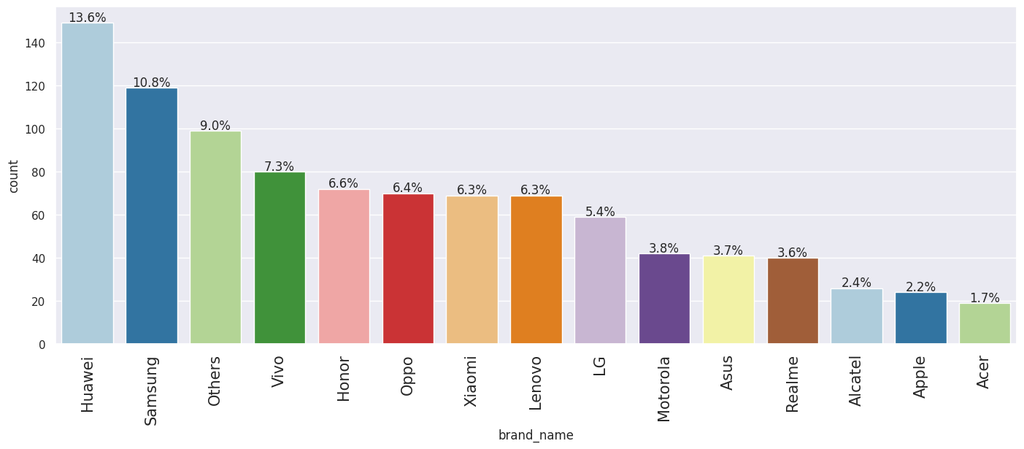

```python
labeled_barplot(df_large_screen, "brand_name", perc=True, n=15)
```

**Brands with Good Camera Resolution**

A good resolution for front cameras would be higher than 8 mp, but for rear cameras, it would be higher than 16 as these cameras tend to have better resolutions than the other. As shown in the barplots below, most of the devices that have good front camera resolution are of Huawei brand. However, those with good rear camera resolutions are mostly Sony devices.

```python
df_selfie_camera = df[df.selfie_camera_mp > 8]
df_selfie_camera.shape
```

```
(655, 15)
```

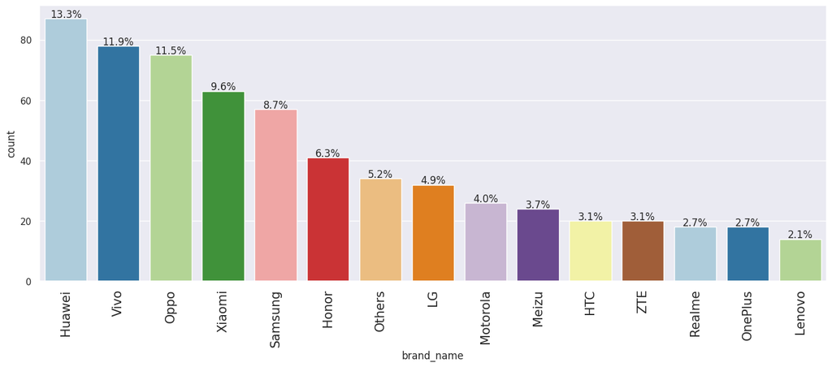

```python
labeled_barplot(df_selfie_camera, "brand_name", perc=True, n=15)
```

```python
df_main_camera = df[df.main_camera_mp > 16]
df_main_camera.shape
```

```
(94, 15)
```

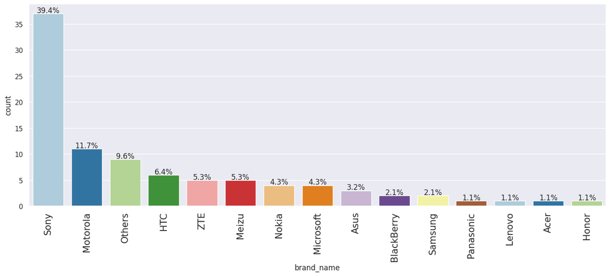

```python
labeled_barplot(df_main_camera, "brand_name", perc=True, n=15)
```

**Amount of RAM Across Brands**

OnePlus devices generally have the most RAM out of the other brands, followed by Honor, Oppo and Realme. Phones and tablets like Nokia and Celkon have below average amount of RAM. However, it should be noted that the devices with 12 GB of RAM that are from Huawei, Motorola, Oneplus, Oppo, Samsung and Xiaomi. Interestingly, for Apple, the most it can offer is 6 GB of RAM.

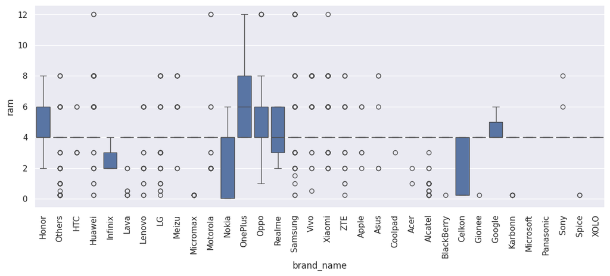

```python
plt.figure(figsize=(14, 5))
sns.boxplot(data=df, x="brand_name", y="ram")
plt.xticks(rotation=90)
plt.show()
```

**Weight of Batteries Across Brands**

```python
df_large_battery = df[df.battery > 4500]
df_large_battery.shape
```

```
(341, 15)
```

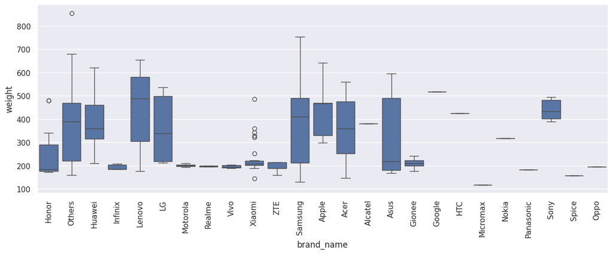

```python
plt.figure(figsize=(15, 5))
sns.boxplot(data=df_large_battery, x="brand_name", y="weight")
plt.xticks(rotation=90)
plt.show()
```

**Prices Over the Years**

The prices across both new and used devices tend to increase the more recent those devices have been released. However, for new ones, those that came out in 2018 cost slightly higher than those of 2019. As expected, used phones cost much cheaper than new phones.

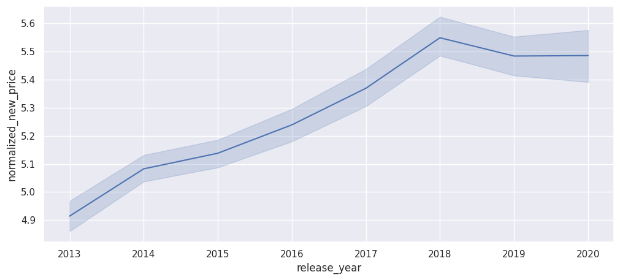

```python
plt.figure(figsize=(12, 5))
sns.lineplot(data=df, x="release_year", y="normalized_new_price")
plt.show()
```

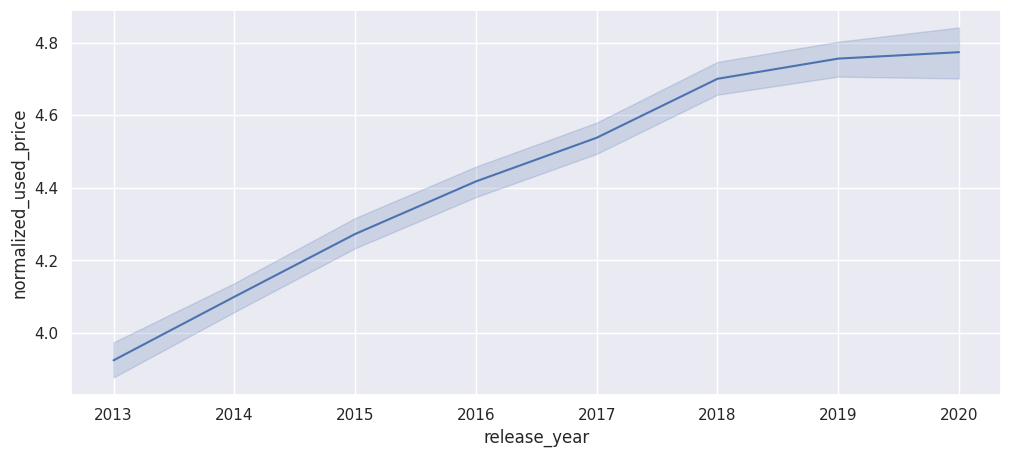

```python
plt.figure(figsize=(12, 5))
sns.lineplot(data=df, x="release_year", y="normalized_used_price")
plt.show()
```

**Correlation Check**

In the heatmap below, it appears that larger screen sizes heavily correlate with larger battery sizes and weights. On the other hand, there is very little to no correlation between ROM or RAM and the weight of the devices.

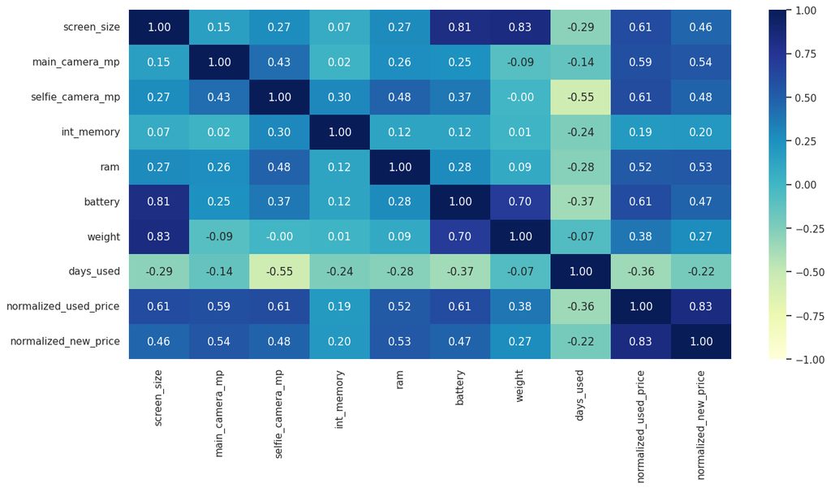

```python
cols_list = df.select_dtypes(include=np.number).columns.tolist()
cols_list.remove("release_year")

plt.figure(figsize=(15, 7))
sns.heatmap(
    df[cols_list].corr(), annot=True, vmin=-1, vmax=1, fmt=".2f", cmap="YlGnBu"
)
plt.show()
```

## **Data Preprocessing**

### Missing Value Imputation

```python
df1 = df.copy()
```

```python
df1.isnull().sum()
```

```
brand_name                 0
os                         0
screen_size                0
4g                         0
5g                         0
main_camera_mp           179
selfie_camera_mp           2
int_memory                 4
ram                        4
battery                    6
weight                     7
release_year               0
days_used                  0
normalized_used_price      0
normalized_new_price       0
dtype: int64
```

```python
## Imputing the missing values by the column medians that are grouped by the 'release_year' and 'brand_name'

cols_impute = [
    "main_camera_mp",
    "selfie_camera_mp",
    "int_memory",
    "ram",
    "battery",
    "weight",
]

for col in cols_impute:
    df1[col] = df1[col].fillna(
        value=df1.groupby(["release_year", "brand_name"])[col].transform("median")
    )

df1.isnull().sum()
```

```
brand_name                 0
os                         0
screen_size                0
4g                         0
5g                         0
main_camera_mp           179
selfie_camera_mp           2
int_memory                 0
ram                        0
battery                    6
weight                     7
release_year               0
days_used                  0
normalized_used_price      0
normalized_new_price       0
dtype: int64
```

```python
## Imputing the remaining missing values by the column medians ground by 'brand_name'

cols_impute = [
    "main_camera_mp",
    "selfie_camera_mp",
    "battery",
    "weight",
]

for col in cols_impute:
    df1[col] = df1[col].fillna(
        value=df1.groupby(["brand_name"])[col].transform("median")
    )

df1.isnull().sum()
```

```
brand_name                0
os                        0
screen_size               0
4g                        0
5g                        0
main_camera_mp           10
selfie_camera_mp          0
int_memory                0
ram                       0
battery                   0
weight                    0
release_year              0
days_used                 0
normalized_used_price     0
normalized_new_price      0
dtype: int64
```

```python
## Imputing the remaining missing values by the 'selfie_camera_mp' column median grouped by 'main_camera_mp'

df1["main_camera_mp"] = df1["main_camera_mp"].fillna(value=df1.groupby(["selfie_camera_mp"])["main_camera_mp"].transform("median"))

df1.isnull().sum()
```

```
brand_name               0
os                       0
screen_size              0
4g                       0
5g                       0
main_camera_mp           0
selfie_camera_mp         0
int_memory               0
ram                      0
battery                  0
weight                   0
release_year             0
days_used                0
normalized_used_price    0
normalized_new_price     0
dtype: int64
```

### Feature Engineering

The year 2021 is used as the baseline to produce `years_since_release`, which will replace the `release_year`.

```python
df1["years_since_release"] = 2021 - df1["release_year"]
df1.drop("release_year", axis=1, inplace=True)
df1["years_since_release"].describe()
```

```
count    3454.000000
mean        5.034742
std         2.298455
min         1.000000
25%         3.000000
50%         5.500000
75%         7.000000
max         8.000000
Name: years_since_release, dtype: float64
```

### Checking for Outliers

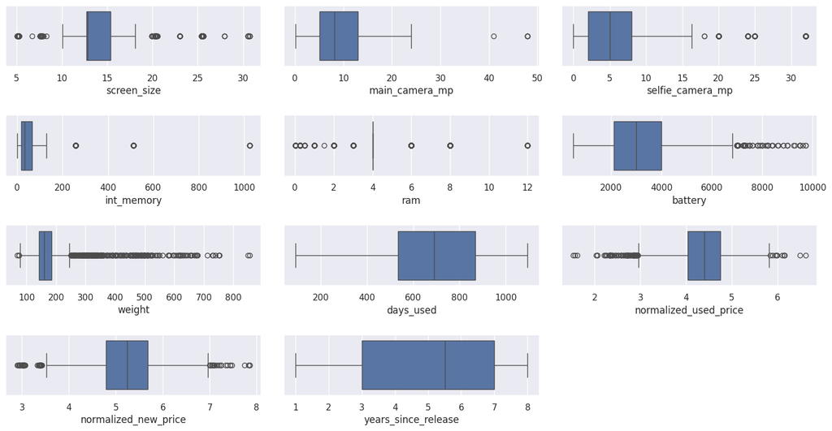

```python
num_cols = df1.select_dtypes(include=np.number).columns.tolist()

plt.figure(figsize=(15, 8))

for i, variable in enumerate(num_cols):
    plt.subplot(4, 3, i + 1)
    sns.boxplot(data=df1, x=variable)
    plt.tight_layout(pad=2)

plt.show()
```

### Data Preparation for modeling

```python
X = df1.drop(["normalized_used_price"], axis=1)
y = df1["normalized_used_price"]

print(X.head())
print(y.head())
```

```
  brand_name       os  screen_size   4g   5g  main_camera_mp  \
0      Honor  Android        14.50  yes   no            13.0
1      Honor  Android        17.30  yes  yes            13.0
2      Honor  Android        16.69  yes  yes            13.0
3      Honor  Android        25.50  yes  yes            13.0
4      Honor  Android        15.32  yes   no            13.0

   selfie_camera_mp  int_memory  ram  battery  weight  days_used  \
0               5.0        64.0  3.0   3020.0   146.0        127
1              16.0       128.0  8.0   4300.0   213.0        325
2               8.0       128.0  8.0   4200.0   213.0        162
3               8.0        64.0  6.0   7250.0   480.0        345
4               8.0        64.0  3.0   5000.0   185.0        293

   normalized_new_price  years_since_release
0              4.715100                    1
1              5.519018                    1
2              5.884631                    1
3              5.630961                    1
4              4.947837                    1
0    4.307572
1    5.162097
2    5.111084
3    5.135387
4    4.389995
Name: normalized_used_price, dtype: float64
```

```python
X = sm.add_constant(X)
```

```python
X = pd.get_dummies(
    X,
    columns=X.select_dtypes(include=["object", "category"]).columns.tolist(),
    drop_first=True,
)

X.head()
```

|  | const | screen_size | main_camera_mp | selfie_camera_mp | int_memory | ram | battery | weight | days_used | normalized_new_price | ... | brand_name_Spice | brand_name_Vivo | brand_name_XOLO | brand_name_Xiaomi | brand_name_ZTE | os_Others | os_Windows | os_iOS | 4g_yes | 5g_yes |
| --- | --- | --- | --- | --- | --- | --- | --- | --- | --- | --- | --- | --- | --- | --- | --- | --- | --- | --- | --- | --- | --- |
| 0 | 1.0 | 14.50 | 13.0 | 5.0 | 64.0 | 3.0 | 3020.0 | 146.0 | 127 | 4.715100 | ... | 0 | 0 | 0 | 0 | 0 | 0 | 0 | 0 | 1 | 0 |
| 1 | 1.0 | 17.30 | 13.0 | 16.0 | 128.0 | 8.0 | 4300.0 | 213.0 | 325 | 5.519018 | ... | 0 | 0 | 0 | 0 | 0 | 0 | 0 | 0 | 1 | 1 |
| 2 | 1.0 | 16.69 | 13.0 | 8.0 | 128.0 | 8.0 | 4200.0 | 213.0 | 162 | 5.884631 | ... | 0 | 0 | 0 | 0 | 0 | 0 | 0 | 0 | 1 | 1 |
| 3 | 1.0 | 25.50 | 13.0 | 8.0 | 64.0 | 6.0 | 7250.0 | 480.0 | 345 | 5.630961 | ... | 0 | 0 | 0 | 0 | 0 | 0 | 0 | 0 | 1 | 1 |
| 4 | 1.0 | 15.32 | 13.0 | 8.0 | 64.0 | 3.0 | 5000.0 | 185.0 | 293 | 4.947837 | ... | 0 | 0 | 0 | 0 | 0 | 0 | 0 | 0 | 1 | 0 |

5 rows × 49 columns

```python
x_train, x_test, y_train, y_test = train_test_split(X, y, test_size=0.3, random_state=1)
```

```python
print("Number of rows in train data =", x_train.shape[0])
print("Number of rows in test data =", x_test.shape[0])
```

```
Number of rows in train data = 2417
Number of rows in test data = 1037
```

### EDA

After manipulating the data, namely around replacing `release_year` with `years_since_release`, one can see that the graphs below look the exact opposite from their previous versions. Instead of the prices (both for new and used devices) going up as the year passes, here, the prices are going down the more years there are.

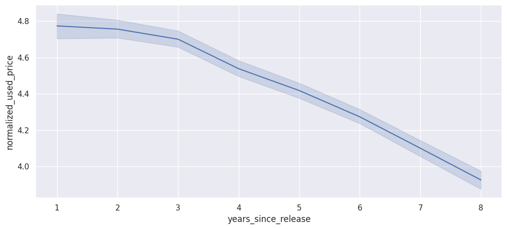

```python
plt.figure(figsize=(12, 5))
sns.lineplot(data=df1, x="years_since_release", y="normalized_used_price")
plt.show()
```

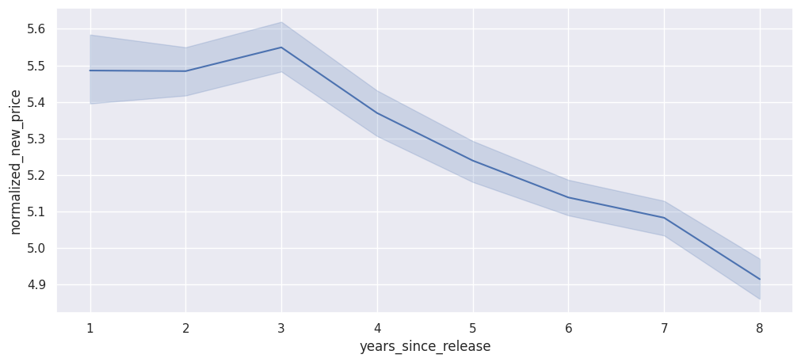

```python
plt.figure(figsize=(12, 5))
sns.lineplot(data=df1, x="years_since_release", y="normalized_new_price")
plt.show()
```

## **Model Building - Linear Regression**

```python
olsmodel1 = sm.OLS(y_train, x_train).fit()
print(olsmodel1.summary())
```

```
                              OLS Regression Results
=================================================================================
Dep. Variable:     normalized_used_price   R-squared:                       0.845
Model:                               OLS   Adj. R-squared:                  0.842
Method:                    Least Squares   F-statistic:                     268.7
Date:                   Sat, 03 Feb 2024   Prob (F-statistic):               0.00
Time:                           00:45:46   Log-Likelihood:                 123.85
No. Observations:                   2417   AIC:                            -149.7
Df Residuals:                       2368   BIC:                             134.0
Df Model:                             48
Covariance Type:               nonrobust
=========================================================================================
                            coef    std err          t      P>|t|      [0.025      0.975]
-----------------------------------------------------------------------------------------
const                     1.3156      0.071     18.454      0.000       1.176       1.455
screen_size               0.0244      0.003      7.163      0.000       0.018       0.031
main_camera_mp            0.0208      0.002     13.848      0.000       0.018       0.024
selfie_camera_mp          0.0135      0.001     11.997      0.000       0.011       0.016
int_memory                0.0001   6.97e-05      1.651      0.099   -2.16e-05       0.000
ram                       0.0230      0.005      4.451      0.000       0.013       0.033
battery               -1.689e-05   7.27e-06     -2.321      0.020   -3.12e-05   -2.62e-06
weight                    0.0010      0.000      7.480      0.000       0.001       0.001
days_used              4.216e-05   3.09e-05      1.366      0.172   -1.84e-05       0.000
normalized_new_price      0.4311      0.012     35.147      0.000       0.407       0.455
years_since_release      -0.0237      0.005     -5.193      0.000      -0.033      -0.015
brand_name_Alcatel        0.0154      0.048      0.323      0.747      -0.078       0.109
brand_name_Apple         -0.0038      0.147     -0.026      0.980      -0.292       0.285
brand_name_Asus           0.0151      0.048      0.314      0.753      -0.079       0.109
brand_name_BlackBerry    -0.0300      0.070     -0.427      0.669      -0.168       0.108
brand_name_Celkon        -0.0468      0.066     -0.707      0.480      -0.177       0.083
brand_name_Coolpad        0.0209      0.073      0.287      0.774      -0.122       0.164
brand_name_Gionee         0.0448      0.058      0.775      0.438      -0.068       0.158
brand_name_Google        -0.0326      0.085     -0.385      0.700      -0.199       0.133
brand_name_HTC           -0.0130      0.048     -0.270      0.787      -0.108       0.081
brand_name_Honor          0.0317      0.049      0.644      0.520      -0.065       0.128
brand_name_Huawei        -0.0020      0.044     -0.046      0.964      -0.089       0.085
brand_name_Infinix        0.0592      0.093      0.634      0.526      -0.124       0.242
brand_name_Karbonn        0.0943      0.067      1.405      0.160      -0.037       0.226
brand_name_LG            -0.0132      0.045     -0.291      0.771      -0.102       0.076
brand_name_Lava           0.0332      0.062      0.533      0.594      -0.089       0.155
```

[output cut: 19 more lines]

```
os_Windows               -0.0207      0.045     -0.459      0.646      -0.109       0.068
os_iOS                   -0.0663      0.146     -0.453      0.651      -0.354       0.221
4g_yes                    0.0528      0.016      3.326      0.001       0.022       0.084
5g_yes                   -0.0714      0.031     -2.268      0.023      -0.133      -0.010
==============================================================================
Omnibus:                      223.612   Durbin-Watson:                   1.910
Prob(Omnibus):                  0.000   Jarque-Bera (JB):              422.275
Skew:                          -0.620   Prob(JB):                     2.01e-92
Kurtosis:                       4.630   Cond. No.                     1.78e+05
==============================================================================

Notes:
[1] Standard Errors assume that the covariance matrix of the errors is correctly specified.
[2] The condition number is large, 1.78e+05. This might indicate that there are
strong multicollinearity or other numerical problems.
```

### Interpreting Regression Results

- The adjusted R-squared for this regression is 0.842, which means that this is a good fit of the model.
- The coefficient of `const` or the y-intercept is 1.3156.
- The predictor variables, or the x-variables, such as `screen_size`, `main_camera_mp`, `ram` and `normalized_new_price`, each have the coefficient values of 0.0244, 0.0208, 0.0230 and 0.4311 respectively.

## **Model Performance Check**

```python
# function to compute adjusted R-squared
def adj_r2_score(predictors, targets, predictions):
    r2 = r2_score(targets, predictions)
    n = predictors.shape[0]
    k = predictors.shape[1]
    return 1 - ((1 - r2) * (n - 1) / (n - k - 1))


# function to compute MAPE
def mape_score(targets, predictions):
    return np.mean(np.abs(targets - predictions) / targets) * 100


# function to compute different metrics to check performance of a regression model
def model_performance_regression(model, predictors, target):
    """
    Function to compute different metrics to check regression model performance

    model: regressor
    predictors: independent variables
    target: dependent variable
    """

    # predicting using the independent variables
    pred = model.predict(predictors)

    r2 = r2_score(target, pred)  # to compute R-squared
    adjr2 = adj_r2_score(predictors, target, pred)  # to compute adjusted R-squared
    rmse = np.sqrt(mean_squared_error(target, pred))  # to compute RMSE
    mae = mean_absolute_error(target, pred)  # to compute MAE
    mape = mape_score(target, pred)  # to compute MAPE

    # creating a dataframe of metrics
    df_perf = pd.DataFrame(
        {
            "RMSE": rmse,
            "MAE": mae,
            "R-squared": r2,
            "Adj. R-squared": adjr2,
            "MAPE": mape,
        },
        index=[0],
    )

    return df_perf
```

```python
print("Training Performance\n")
olsmodel1_train_perf = model_performance_regression(olsmodel1, x_train, y_train)
olsmodel1_train_perf
```

```
Training Performance
```

|  | RMSE | MAE | R-squared | Adj. R-squared | MAPE |
| --- | --- | --- | --- | --- | --- |
| 0 | 0.229884 | 0.180326 | 0.844886 | 0.841675 | 4.326841 |

```python
print("Test Performance\n")
olsmodel1_test_perf = model_performance_regression(olsmodel1, x_test, y_test)
olsmodel1_test_perf
```

```
Test Performance
```

|  | RMSE | MAE | R-squared | Adj. R-squared | MAPE |
| --- | --- | --- | --- | --- | --- |
| 0 | 0.238358 | 0.184749 | 0.842479 | 0.834659 | 4.501651 |

### **Observations**

- The training R-squared is about 0.845 and the testing R-squared is about 0.843, meaning the model is not underfitting and actually fits well with the data.
- The training and testing RMSE and MAE are also similar, so the model is not overfitting.
- The value of the testing MAE means that the model can predict the price of used devices within a mean error of 0.185.
- The value of the testing MAPE shows that the model can predict within 4.502% of the prices of used devices.

## **Checking Linear Regression Assumptions**

### Test for Multicollinearity

While most variables have VIF values lesser than 5, there are a few that are higher, indicating signs of moderate to high multicollinearity among those variables.

```python
from statsmodels.stats.outliers_influence import variance_inflation_factor

def checking_vif(predictors):
    vif = pd.DataFrame()
    vif["feature"] = predictors.columns

    # calculating VIF for each feature
    vif["VIF"] = [
        variance_inflation_factor(predictors.values, i)
        for i in range(len(predictors.columns))
    ]
    return vif
```

```python
checking_vif(x_train)
```

|  | feature | VIF |
| --- | --- | --- |
| 0 | const | 227.744081 |
| 1 | screen_size | 7.677290 |
| 2 | main_camera_mp | 2.288130 |
| 3 | selfie_camera_mp | 2.812473 |
| 4 | int_memory | 1.364152 |
| 5 | ram | 2.282352 |
| 6 | battery | 4.081780 |
| 7 | weight | 6.396749 |
| 8 | days_used | 2.660269 |
| 9 | normalized_new_price | 3.119430 |
| 10 | years_since_release | 4.899007 |
| 11 | brand_name_Alcatel | 3.405693 |
| 12 | brand_name_Apple | 13.057668 |
| 13 | brand_name_Asus | 3.332038 |
| 14 | brand_name_BlackBerry | 1.632378 |
| 15 | brand_name_Celkon | 1.774721 |
| 16 | brand_name_Coolpad | 1.468006 |
| 17 | brand_name_Gionee | 1.951272 |
| 18 | brand_name_Google | 1.321778 |
| 19 | brand_name_HTC | 3.410361 |
| 20 | brand_name_Honor | 3.340687 |
| 21 | brand_name_Huawei | 5.983852 |
| 22 | brand_name_Infinix | 1.287877 |
| 23 | brand_name_Karbonn | 1.573702 |
| 24 | brand_name_LG | 4.849832 |
| 25 | brand_name_Lava | 1.711360 |
| 26 | brand_name_Lenovo | 4.558941 |
| 27 | brand_name_Meizu | 2.179607 |
| 28 | brand_name_Micromax | 3.363521 |
| 29 | brand_name_Microsoft | 1.869751 |
| 30 | brand_name_Motorola | 3.274558 |
| 31 | brand_name_Nokia | 3.479849 |
| 32 | brand_name_OnePlus | 1.437034 |
| 33 | brand_name_Oppo | 3.971194 |
| 34 | brand_name_Others | 9.711034 |
| 35 | brand_name_Panasonic | 2.105703 |
| 36 | brand_name_Realme | 1.946812 |
| 37 | brand_name_Samsung | 7.539866 |
| 38 | brand_name_Sony | 2.943161 |
| 39 | brand_name_Spice | 1.688863 |
| 40 | brand_name_Vivo | 3.651437 |
| 41 | brand_name_XOLO | 2.138070 |
| 42 | brand_name_Xiaomi | 3.719689 |
| 43 | brand_name_ZTE | 3.797581 |
| 44 | os_Others | 1.859863 |
| 45 | os_Windows | 1.596034 |
| 46 | os_iOS | 11.784684 |
| 47 | 4g_yes | 2.467681 |
| 48 | 5g_yes | 1.813900 |

### Removing Multicollinearity

Removing mulitcollinearity from the model requires dropping columns whose Variance Inflation Factor (VIF) value is greater than 5. Dummy variables and the intercept are ignored. As `screen_size` and `weight` both have their VIF values higher than 5, they will be dropped.

```python
def treating_multicollinearity(predictors, target, high_vif_columns):
    """
    Checking the effect of dropping the columns showing high multicollinearity
    on model performance (adj. R-squared and RMSE)

    predictors: independent variables
    target: dependent variable
    high_vif_columns: columns having high VIF
    """
    adj_r2 = []
    rmse = []

    for cols in high_vif_columns:
        train = predictors.loc[:, ~predictors.columns.str.startswith(cols)]

        olsmodel = sm.OLS(target, train).fit()

        adj_r2.append(olsmodel.rsquared_adj)
        rmse.append(np.sqrt(olsmodel.mse_resid))

    temp = pd.DataFrame(
        {
            "col": high_vif_columns,
            "Adj. R-squared after_dropping col": adj_r2,
            "RMSE after dropping col": rmse,
        }
    ).sort_values(by="Adj. R-squared after_dropping col", ascending=False)
    temp.reset_index(drop=True, inplace=True)

    return temp
```

```python
col_list = ["screen_size", "weight"]

res = treating_multicollinearity(x_train, y_train, col_list)
res
```

|  | col | Adj. R-squared after_dropping col | RMSE after dropping col |
| --- | --- | --- | --- |
| 0 | screen_size | 0.838381 | 0.234703 |
| 1 | weight | 0.838071 | 0.234928 |

```python
col_to_drop = "screen_size"
x_train2 = x_train.loc[:, ~x_train.columns.str.startswith(col_to_drop)]
x_test2 = x_test.loc[:, ~x_test.columns.str.startswith(col_to_drop)]

vif = checking_vif(x_train2)
print("VIF after dropping ", col_to_drop)
vif
```

```
VIF after dropping  screen_size
```

|  | feature | VIF |
| --- | --- | --- |
| 0 | const | 202.673906 |
| 1 | main_camera_mp | 2.284910 |
| 2 | selfie_camera_mp | 2.809009 |
| 3 | int_memory | 1.362043 |
| 4 | ram | 2.282350 |
| 5 | battery | 3.842989 |
| 6 | weight | 2.993855 |
| 7 | days_used | 2.648929 |
| 8 | normalized_new_price | 3.077650 |
| 9 | years_since_release | 4.730315 |
| 10 | brand_name_Alcatel | 3.405533 |
| 11 | brand_name_Apple | 13.000338 |
| 12 | brand_name_Asus | 3.326698 |
| 13 | brand_name_BlackBerry | 1.631042 |
| 14 | brand_name_Celkon | 1.774528 |
| 15 | brand_name_Coolpad | 1.467719 |
| 16 | brand_name_Gionee | 1.941437 |
| 17 | brand_name_Google | 1.319334 |
| 18 | brand_name_HTC | 3.399980 |
| 19 | brand_name_Honor | 3.340354 |
| 20 | brand_name_Huawei | 5.981046 |
| 21 | brand_name_Infinix | 1.287294 |
| 22 | brand_name_Karbonn | 1.573494 |
| 23 | brand_name_LG | 4.832548 |
| 24 | brand_name_Lava | 1.711092 |
| 25 | brand_name_Lenovo | 4.553789 |
| 26 | brand_name_Meizu | 2.176424 |
| 27 | brand_name_Micromax | 3.358629 |
| 28 | brand_name_Microsoft | 1.868243 |
| 29 | brand_name_Motorola | 3.262356 |
| 30 | brand_name_Nokia | 3.464643 |
| 31 | brand_name_OnePlus | 1.437004 |
| 32 | brand_name_Oppo | 3.965445 |
| 33 | brand_name_Others | 9.652572 |
| 34 | brand_name_Panasonic | 2.104853 |
| 35 | brand_name_Realme | 1.943845 |
| 36 | brand_name_Samsung | 7.523421 |
| 37 | brand_name_Sony | 2.937375 |
| 38 | brand_name_Spice | 1.683302 |
| 39 | brand_name_Vivo | 3.650625 |
| 40 | brand_name_XOLO | 2.137844 |
| 41 | brand_name_Xiaomi | 3.713988 |
| 42 | brand_name_ZTE | 3.788971 |
| 43 | os_Others | 1.625212 |
| 44 | os_Windows | 1.595936 |
| 45 | os_iOS | 11.678957 |
| 46 | 4g_yes | 2.466915 |
| 47 | 5g_yes | 1.810289 |

```python
olsmodel1 = sm.OLS(y_train, x_train2).fit()
print(olsmodel1.summary())
```

```
                              OLS Regression Results
=================================================================================
Dep. Variable:     normalized_used_price   R-squared:                       0.842
Model:                               OLS   Adj. R-squared:                  0.838
Method:                    Least Squares   F-statistic:                     267.7
Date:                   Sat, 03 Feb 2024   Prob (F-statistic):               0.00
Time:                           00:45:48   Log-Likelihood:                 97.950
No. Observations:                   2417   AIC:                            -99.90
Df Residuals:                       2369   BIC:                             178.0
Df Model:                             47
Covariance Type:               nonrobust
=========================================================================================
                            coef    std err          t      P>|t|      [0.025      0.975]
-----------------------------------------------------------------------------------------
const                     1.4851      0.068     21.851      0.000       1.352       1.618
main_camera_mp            0.0212      0.002     13.979      0.000       0.018       0.024
selfie_camera_mp          0.0138      0.001     12.128      0.000       0.012       0.016
int_memory             9.551e-05   7.04e-05      1.356      0.175   -4.26e-05       0.000
ram                       0.0229      0.005      4.397      0.000       0.013       0.033
battery               -4.284e-06   7.13e-06     -0.601      0.548   -1.83e-05     9.7e-06
weight                    0.0017   9.22e-05     18.376      0.000       0.002       0.002
days_used              2.773e-05   3.11e-05      0.891      0.373   -3.33e-05    8.88e-05
normalized_new_price      0.4413      0.012     35.841      0.000       0.417       0.465
years_since_release      -0.0297      0.005     -6.568      0.000      -0.039      -0.021
brand_name_Alcatel        0.0177      0.048      0.368      0.713      -0.077       0.112
brand_name_Apple          0.0660      0.148      0.445      0.656      -0.225       0.357
brand_name_Asus           0.0013      0.048      0.027      0.978      -0.094       0.096
brand_name_BlackBerry    -0.0444      0.071     -0.626      0.531      -0.183       0.095
brand_name_Celkon        -0.0518      0.067     -0.773      0.440      -0.183       0.080
brand_name_Coolpad        0.0136      0.074      0.185      0.854      -0.131       0.158
brand_name_Gionee         0.0154      0.058      0.265      0.791      -0.099       0.130
brand_name_Google        -0.0587      0.085     -0.687      0.492      -0.226       0.109
brand_name_HTC           -0.0321      0.049     -0.660      0.509      -0.127       0.063
brand_name_Honor          0.0352      0.050      0.708      0.479      -0.062       0.133
brand_name_Huawei        -0.0089      0.045     -0.199      0.842      -0.097       0.079
brand_name_Infinix        0.0450      0.094      0.477      0.634      -0.140       0.230
brand_name_Karbonn        0.0998      0.068      1.472      0.141      -0.033       0.233
brand_name_LG            -0.0325      0.046     -0.712      0.476      -0.122       0.057
brand_name_Lava           0.0276      0.063      0.438      0.661      -0.096       0.151
brand_name_Lenovo         0.0345      0.046      0.756      0.450      -0.055       0.124
```

[output cut: 18 more lines]

```
os_Windows               -0.0182      0.046     -0.399      0.690      -0.108       0.071
os_iOS                   -0.1657      0.147     -1.125      0.261      -0.455       0.123
4g_yes                    0.0508      0.016      3.167      0.002       0.019       0.082
5g_yes                   -0.0815      0.032     -2.563      0.010      -0.144      -0.019
==============================================================================
Omnibus:                      234.761   Durbin-Watson:                   1.907
Prob(Omnibus):                  0.000   Jarque-Bera (JB):              440.912
Skew:                          -0.647   Prob(JB):                     1.81e-96
Kurtosis:                       4.644   Cond. No.                     1.78e+05
==============================================================================

Notes:
[1] Standard Errors assume that the covariance matrix of the errors is correctly specified.
[2] The condition number is large, 1.78e+05. This might indicate that there are
strong multicollinearity or other numerical problems.
```

### Dropping High P-Value Variables

```python
predictors = x_train2.copy()
cols = predictors.columns.tolist()

max_p_value = 1

while len(cols) > 0:
    x_train_aux = predictors[cols]

    model = sm.OLS(y_train, x_train_aux).fit()

    p_values = model.pvalues
    max_p_value = max(p_values)

    feature_with_p_max = p_values.idxmax()

    if max_p_value > 0.05:
        cols.remove(feature_with_p_max)
    else:
        break

selected_features = cols
print(selected_features)
```

```
['const', 'main_camera_mp', 'selfie_camera_mp', 'ram', 'weight', 'normalized_new_price', 'years_since_release', 'brand_name_Karbonn', 'brand_name_Samsung', 'brand_name_Sony', 'brand_name_Xiaomi', 'os_Others', 'os_iOS', '4g_yes', '5g_yes']
```

```python
x_train3 = x_train2[selected_features]
x_test3 = x_test2[selected_features]
```

```python
olsmodel2 = sm.OLS(y_train, x_train3).fit()
print(olsmodel2.summary())
```

```
                              OLS Regression Results
=================================================================================
Dep. Variable:     normalized_used_price   R-squared:                       0.839
Model:                               OLS   Adj. R-squared:                  0.838
Method:                    Least Squares   F-statistic:                     896.9
Date:                   Sat, 03 Feb 2024   Prob (F-statistic):               0.00
Time:                           00:45:49   Log-Likelihood:                 82.004
No. Observations:                   2417   AIC:                            -134.0
Df Residuals:                       2402   BIC:                            -47.15
Df Model:                             14
Covariance Type:               nonrobust
========================================================================================
                           coef    std err          t      P>|t|      [0.025      0.975]
----------------------------------------------------------------------------------------
const                    1.4939      0.048     30.884      0.000       1.399       1.589
main_camera_mp           0.0211      0.001     14.814      0.000       0.018       0.024
selfie_camera_mp         0.0138      0.001     12.838      0.000       0.012       0.016
ram                      0.0211      0.005      4.223      0.000       0.011       0.031
weight                   0.0017      6e-05     27.698      0.000       0.002       0.002
normalized_new_price     0.4419      0.011     39.458      0.000       0.420       0.464
years_since_release     -0.0289      0.003     -8.496      0.000      -0.036      -0.022
brand_name_Karbonn       0.1155      0.055      2.110      0.035       0.008       0.223
brand_name_Samsung      -0.0373      0.016     -2.261      0.024      -0.070      -0.005
brand_name_Sony         -0.0673      0.030     -2.210      0.027      -0.127      -0.008
brand_name_Xiaomi        0.0806      0.026      3.139      0.002       0.030       0.131
os_Others               -0.1258      0.027     -4.603      0.000      -0.179      -0.072
os_iOS                  -0.0897      0.045     -1.988      0.047      -0.178      -0.001
4g_yes                   0.0498      0.015      3.299      0.001       0.020       0.079
5g_yes                  -0.0671      0.031     -2.189      0.029      -0.127      -0.007
==============================================================================
Omnibus:                      245.329   Durbin-Watson:                   1.901
Prob(Omnibus):                  0.000   Jarque-Bera (JB):              481.790
Skew:                          -0.656   Prob(JB):                    2.40e-105
Kurtosis:                       4.749   Cond. No.                     2.39e+03
==============================================================================

Notes:
[1] Standard Errors assume that the covariance matrix of the errors is correctly specified.
[2] The condition number is large, 2.39e+03. This might indicate that there are
strong multicollinearity or other numerical problems.
```

```python
print("Training Performance\n")
olsmodel2_train_perf = model_performance_regression(olsmodel2, x_train3, y_train)
olsmodel2_train_perf
```

```
Training Performance
```

|  | RMSE | MAE | R-squared | Adj. R-squared | MAPE |
| --- | --- | --- | --- | --- | --- |
| 0 | 0.233899 | 0.18258 | 0.83942 | 0.838417 | 4.390995 |

```python
print("Test Performance\n")
olsmodel2_test_perf = model_performance_regression(olsmodel2,x_test3, y_test)
olsmodel2_test_perf
```

```
Test Performance
```

|  | RMSE | MAE | R-squared | Adj. R-squared | MAPE |
| --- | --- | --- | --- | --- | --- |
| 0 | 0.241334 | 0.186517 | 0.838521 | 0.836149 | 4.552676 |

### Test for Linearity and Independence

```python
df_pred = pd.DataFrame()

df_pred["Actual Values"] = y_train
df_pred["Fitted Values"] = olsmodel2.fittedvalues
df_pred["Residuals"] = olsmodel2.resid

df_pred.head()
```

|  | Actual Values | Fitted Values | Residuals |
| --- | --- | --- | --- |
| 3026 | 4.087488 | 3.867608 | 0.219879 |
| 1525 | 4.448399 | 4.601899 | -0.153499 |
| 1128 | 4.315353 | 4.287503 | 0.027850 |
| 3003 | 4.282068 | 4.194722 | 0.087346 |
| 2907 | 4.456438 | 4.489680 | -0.033242 |

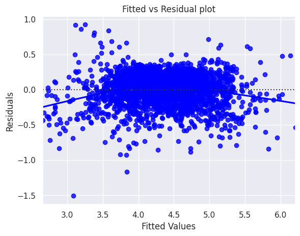

```python
sns.residplot(
    data=df_pred, x="Fitted Values", y="Residuals", color="blue", lowess=True
)
plt.xlabel("Fitted Values")
plt.ylabel("Residuals")
plt.title("Fitted vs Residual plot")
plt.show()
```

#### **Observation**

Because the plot above demonstrates no strong correlation or pattern, the assumptions of linearity and independence are satisfied, meaning the model is linear and residuals are independent.

### Test for Normality

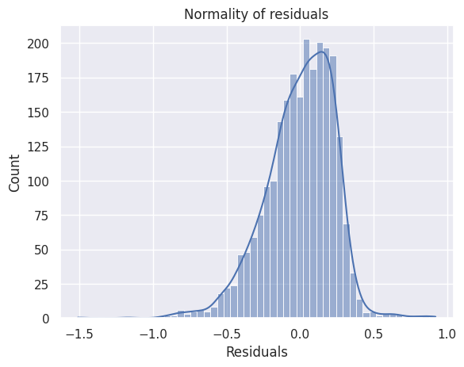

```python
sns.histplot(data=df_pred, x="Residuals", kde=True)
plt.title("Normality of residuals")
plt.show()
```

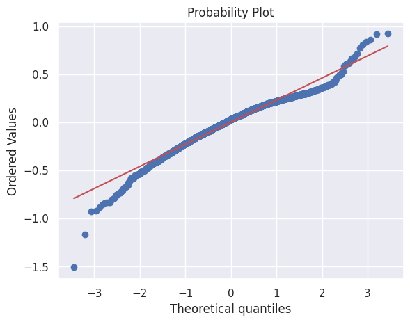

```python
import pylab
import scipy.stats as stats

stats.probplot(df_pred["Residuals"], dist="norm", plot=pylab)
plt.show()
```

```python
stats.shapiro(df_pred["Residuals"])
```

```
ShapiroResult(statistic=0.967808723449707, pvalue=7.634907598558696e-23)
```

#### **Observations**

- The histogram of the residuals shares a bell-shaped curve, although it has a few outliers at the -1.5 range.
- The Q-Q plot shows that the residuals follow along the straight line except for the tails.
- The Shapiro-Wilk test indicates that the residuals are not necessarily normal because the p-value is way less than 0.05. However, given earlier observation, one can say that the distribution is approximately close enough to be considered as normal, so the normality assumption is satisfied.

### Test for Homoscedasticity

```python
import statsmodels.stats.api as sms
from statsmodels.compat import lzip

name = ["F statistic", "p-value"]
test = sms.het_goldfeldquandt(df_pred["Residuals"], x_train3)
lzip(name, test)
```

```
[('F statistic', 1.009794401185382), ('p-value', 0.43316051505003356)]
```

#### **Observation**

Because the p-value is larger than 0.05, it is safe to conclude that the residuals are homoscedastic. So, this assumption is satisfied.

### Predictions on Test Data

```python
pred = olsmodel2.predict(x_test3)

df_pred_test = pd.DataFrame({"Actual": y_test, "Predicted": pred})
df_pred_test.sample(10, random_state=1)
```

|  | Actual | Predicted |
| --- | --- | --- |
| 1995 | 4.566741 | 4.385785 |
| 2341 | 3.696103 | 4.004228 |
| 1913 | 3.592093 | 3.643963 |
| 688 | 4.306495 | 4.103349 |
| 650 | 4.522115 | 5.113311 |
| 2291 | 4.259294 | 4.398582 |
| 40 | 4.997685 | 5.459657 |
| 1884 | 3.875359 | 4.053145 |
| 2538 | 4.206631 | 4.036203 |
| 45 | 5.380450 | 5.227833 |

My model is pretty good enough as the predicted values are quite close to the actual ones.

## **Final Model Summary**

```python
x_train_final = x_train3.copy()
x_test_final = x_test3.copy()
```

```python
olsmodel_final = sm.OLS(y_train, x_train_final).fit()
print(olsmodel_final.summary())
```

```
                              OLS Regression Results
=================================================================================
Dep. Variable:     normalized_used_price   R-squared:                       0.839
Model:                               OLS   Adj. R-squared:                  0.838
Method:                    Least Squares   F-statistic:                     896.9
Date:                   Sat, 03 Feb 2024   Prob (F-statistic):               0.00
Time:                           00:45:52   Log-Likelihood:                 82.004
No. Observations:                   2417   AIC:                            -134.0
Df Residuals:                       2402   BIC:                            -47.15
Df Model:                             14
Covariance Type:               nonrobust
========================================================================================
                           coef    std err          t      P>|t|      [0.025      0.975]
----------------------------------------------------------------------------------------
const                    1.4939      0.048     30.884      0.000       1.399       1.589
main_camera_mp           0.0211      0.001     14.814      0.000       0.018       0.024
selfie_camera_mp         0.0138      0.001     12.838      0.000       0.012       0.016
ram                      0.0211      0.005      4.223      0.000       0.011       0.031
weight                   0.0017      6e-05     27.698      0.000       0.002       0.002
normalized_new_price     0.4419      0.011     39.458      0.000       0.420       0.464
years_since_release     -0.0289      0.003     -8.496      0.000      -0.036      -0.022
brand_name_Karbonn       0.1155      0.055      2.110      0.035       0.008       0.223
brand_name_Samsung      -0.0373      0.016     -2.261      0.024      -0.070      -0.005
brand_name_Sony         -0.0673      0.030     -2.210      0.027      -0.127      -0.008
brand_name_Xiaomi        0.0806      0.026      3.139      0.002       0.030       0.131
os_Others               -0.1258      0.027     -4.603      0.000      -0.179      -0.072
os_iOS                  -0.0897      0.045     -1.988      0.047      -0.178      -0.001
4g_yes                   0.0498      0.015      3.299      0.001       0.020       0.079
5g_yes                  -0.0671      0.031     -2.189      0.029      -0.127      -0.007
==============================================================================
Omnibus:                      245.329   Durbin-Watson:                   1.901
Prob(Omnibus):                  0.000   Jarque-Bera (JB):              481.790
Skew:                          -0.656   Prob(JB):                    2.40e-105
Kurtosis:                       4.749   Cond. No.                     2.39e+03
==============================================================================

Notes:
[1] Standard Errors assume that the covariance matrix of the errors is correctly specified.
[2] The condition number is large, 2.39e+03. This might indicate that there are
strong multicollinearity or other numerical problems.
```

```python
print("Training Performance\n")
olsmodel_final_train_perf = model_performance_regression(olsmodel_final, x_train_final, y_train)
olsmodel_final_train_perf
```

```
Training Performance
```

|  | RMSE | MAE | R-squared | Adj. R-squared | MAPE |
| --- | --- | --- | --- | --- | --- |
| 0 | 0.233899 | 0.18258 | 0.83942 | 0.838417 | 4.390995 |

```python
print("Test Performance\n")
olsmodel_final_test_perf = model_performance_regression(olsmodel_final, x_test_final, y_test)
olsmodel_final_test_perf
```

```
Test Performance
```

|  | RMSE | MAE | R-squared | Adj. R-squared | MAPE |
| --- | --- | --- | --- | --- | --- |
| 0 | 0.241334 | 0.186517 | 0.838521 | 0.836149 | 4.552676 |

### **Observations**

- The adjusted R-squared is around 0.84 for both the train and test sets.
- The train and test RMSE and MAE are similar and quite low, so the model is not overfitting. The test MAPE indicates that one can predict within 4.55% of the price of used devices.

## **Actionable Insights and Recommendations**

- The final model can explain about 84% of the variation in the data and within 4.55% of the price of used devices on the test data. This proves that the model is good enough to be used as a predictor.
- Based on the final regression, if the rear and front camera resolutions increase by one unit (megapixel), then the price of the used device increases by 0.0211 and 0.0138 units (euros) respectively, all other variables held constant. If the weight increases by one gram, then the price increases by 0.0017 euros. Additionally, if the price of the new device increases by one euro, then the price of the used one also increases by 0.4419. However, the price of a used device will decrease by 0.0289 for every year has passed since that device's release.
- Brands like Karbonn and Xiaomi have positive coefficients, as compared to others (i.e., Samsung and Sony), implying that they will have a slight increased effect on the price of refurbished devices.
- Interestingly, if the used phone or tablet has 5g, the price will be 0.0671 euros less, but if it has 4g, then the price will increase by 0.0498 euros.

As for recommendation, the comapny should sell any used phone or tablet that has larger camera resolutions (both front and back) and more RAM storage. Selling newly made phones and ones that aso has 4g is also advisable. One thing I am skeptical about is the brand of the phones, like Karbonn and Xiaomi; although they seem to have a positive effect on the pricing, they are not widely known enough to attract people to buy their products, as opposed to Samsung and Apple.

# **Supervised Learning - Foundations Project: ReCell**

## **Problem Statement**

### Business Context

Buying and selling used phones and tablets used to be something that happened on a handful of online marketplace sites. But the used and refurbished device market has grown considerably over the past decade, and a new IDC (International Data Corporation) forecast predicts that the used phone market would be worth \$52.7bn by 2023 with a compound annual growth rate (CAGR) of 13.6% from 2018 to 2023. This growth can be attributed to an uptick in demand for used phones and tablets that offer considerable savings compared with new models.

Refurbished and used devices continue to provide cost-effective alternatives to both consumers and businesses that are looking to save money when purchasing one. There are plenty of other benefits associated with the used device market. Used and refurbished devices can be sold with warranties and can also be insured with proof of purchase. Third-party vendors/platforms, such as Verizon, Amazon, etc., provide attractive offers to customers for refurbished devices. Maximizing the longevity of devices through second-hand trade also reduces their environmental impact and helps in recycling and reducing waste. The impact of the COVID-19 outbreak may further boost this segment as consumers cut back on discretionary spending and buy phones and tablets only for immediate needs.

### Objective

The rising potential of this comparatively under-the-radar market fuels the need for an ML-based solution to develop a dynamic pricing strategy for used and refurbished devices. ReCell, a startup aiming to tap the potential in this market, has hired you as a data scientist. They want you to analyze the data provided and build a linear regression model to predict the price of a used phone/tablet and identify factors that significantly influence it.

### Data Description

The data contains the different attributes of used/refurbished phones and tablets. The data was collected in the year 2021. The detailed data dictionary is given below.

- brand_name: Name of manufacturing brand
- os: OS on which the device runs
- screen_size: Size of the screen in cm
- 4g: Whether 4G is available or not
- 5g: Whether 5G is available or not
- main_camera_mp: Resolution of the rear camera in megapixels
- selfie_camera_mp: Resolution of the front camera in megapixels
- int_memory: Amount of internal memory (ROM) in GB
- ram: Amount of RAM in GB
- battery: Energy capacity of the device battery in mAh
- weight: Weight of the device in grams
- release_year: Year when the device model was released
- days_used: Number of days the used/refurbished device has been used
- normalized_new_price: Normalized price of a new device of the same model in euros
- normalized_used_price: Normalized price of the used/refurbished device in euros

## **Setting Up**

```python
import numpy as np
import pandas as pd

import matplotlib.pyplot as plt
import seaborn as sns

sns.set()

from sklearn.model_selection import train_test_split

from sklearn.linear_model import LinearRegression

from sklearn.metrics import mean_absolute_error, mean_squared_error, r2_score

import statsmodels.api as sm

from statsmodels.stats.outliers_influence import variance_inflation_factor
```

```python
import warnings
warnings.simplefilter(action='ignore', category=FutureWarning)
```

```python
from google.colab import drive
drive.mount('/content/drive')
```

```python
df = pd.read_csv('/content/drive/MyDrive/Data Science & Business Analytics Program/Supervised Learning/Project/used_device_data.csv')
```

## **Data Overview**

### **Shape and Statistical Summary of Data**

```python
df.head()
```

|  | brand_name | os | screen_size | 4g | 5g | main_camera_mp | selfie_camera_mp | int_memory | ram | battery | weight | release_year | days_used | normalized_used_price | normalized_new_price |
| --- | --- | --- | --- | --- | --- | --- | --- | --- | --- | --- | --- | --- | --- | --- | --- |
| 0 | Honor | Android | 14.50 | yes | no | 13.0 | 5.0 | 64.0 | 3.0 | 3020.0 | 146.0 | 2020 | 127 | 4.307572 | 4.715100 |
| 1 | Honor | Android | 17.30 | yes | yes | 13.0 | 16.0 | 128.0 | 8.0 | 4300.0 | 213.0 | 2020 | 325 | 5.162097 | 5.519018 |
| 2 | Honor | Android | 16.69 | yes | yes | 13.0 | 8.0 | 128.0 | 8.0 | 4200.0 | 213.0 | 2020 | 162 | 5.111084 | 5.884631 |
| 3 | Honor | Android | 25.50 | yes | yes | 13.0 | 8.0 | 64.0 | 6.0 | 7250.0 | 480.0 | 2020 | 345 | 5.135387 | 5.630961 |
| 4 | Honor | Android | 15.32 | yes | no | 13.0 | 8.0 | 64.0 | 3.0 | 5000.0 | 185.0 | 2020 | 293 | 4.389995 | 4.947837 |

```python
df.shape
```

```
(3454, 15)
```

```python
df.info()
```

```
<class 'pandas.core.frame.DataFrame'>
RangeIndex: 3454 entries, 0 to 3453
Data columns (total 15 columns):
 #   Column                 Non-Null Count  Dtype
---  ------                 --------------  -----
 0   brand_name             3454 non-null   object
 1   os                     3454 non-null   object
 2   screen_size            3454 non-null   float64
 3   4g                     3454 non-null   object
 4   5g                     3454 non-null   object
 5   main_camera_mp         3275 non-null   float64
 6   selfie_camera_mp       3452 non-null   float64
 7   int_memory             3450 non-null   float64
 8   ram                    3450 non-null   float64
 9   battery                3448 non-null   float64
 10  weight                 3447 non-null   float64
 11  release_year           3454 non-null   int64
 12  days_used              3454 non-null   int64
 13  normalized_used_price  3454 non-null   float64
 14  normalized_new_price   3454 non-null   float64
dtypes: float64(9), int64(2), object(4)
memory usage: 404.9+ KB
```

```python
df.describe(include="all").T
```

|  | count | unique | top | freq | mean | std | min | 25% | 50% | 75% | max |
| --- | --- | --- | --- | --- | --- | --- | --- | --- | --- | --- | --- |
| brand_name | 3454 | 34 | Others | 502 | NaN | NaN | NaN | NaN | NaN | NaN | NaN |
| os | 3454 | 4 | Android | 3214 | NaN | NaN | NaN | NaN | NaN | NaN | NaN |
| screen_size | 3454.0 | NaN | NaN | NaN | 13.713115 | 3.80528 | 5.08 | 12.7 | 12.83 | 15.34 | 30.71 |
| 4g | 3454 | 2 | yes | 2335 | NaN | NaN | NaN | NaN | NaN | NaN | NaN |
| 5g | 3454 | 2 | no | 3302 | NaN | NaN | NaN | NaN | NaN | NaN | NaN |
| main_camera_mp | 3275.0 | NaN | NaN | NaN | 9.460208 | 4.815461 | 0.08 | 5.0 | 8.0 | 13.0 | 48.0 |
| selfie_camera_mp | 3452.0 | NaN | NaN | NaN | 6.554229 | 6.970372 | 0.0 | 2.0 | 5.0 | 8.0 | 32.0 |
| int_memory | 3450.0 | NaN | NaN | NaN | 54.573099 | 84.972371 | 0.01 | 16.0 | 32.0 | 64.0 | 1024.0 |
| ram | 3450.0 | NaN | NaN | NaN | 4.036122 | 1.365105 | 0.02 | 4.0 | 4.0 | 4.0 | 12.0 |
| battery | 3448.0 | NaN | NaN | NaN | 3133.402697 | 1299.682844 | 500.0 | 2100.0 | 3000.0 | 4000.0 | 9720.0 |
| weight | 3447.0 | NaN | NaN | NaN | 182.751871 | 88.413228 | 69.0 | 142.0 | 160.0 | 185.0 | 855.0 |
| release_year | 3454.0 | NaN | NaN | NaN | 2015.965258 | 2.298455 | 2013.0 | 2014.0 | 2015.5 | 2018.0 | 2020.0 |
| days_used | 3454.0 | NaN | NaN | NaN | 674.869716 | 248.580166 | 91.0 | 533.5 | 690.5 | 868.75 | 1094.0 |
| normalized_used_price | 3454.0 | NaN | NaN | NaN | 4.364712 | 0.588914 | 1.536867 | 4.033931 | 4.405133 | 4.7557 | 6.619433 |
| normalized_new_price | 3454.0 | NaN | NaN | NaN | 5.233107 | 0.683637 | 2.901422 | 4.790342 | 5.245892 | 5.673718 | 7.847841 |

### **Checking for Missing or Values**

```python
df.isnull().sum()
```

```
brand_name                 0
os                         0
screen_size                0
4g                         0
5g                         0
main_camera_mp           179
selfie_camera_mp           2
int_memory                 4
ram                        4
battery                    6
weight                     7
release_year               0
days_used                  0
normalized_used_price      0
normalized_new_price       0
dtype: int64
```

```python
df.duplicated().sum()
```

```
0
```

```python
data = df.copy()
```